# ggplot ile Veri Görselleştirme

# Giriş

R kurulumu ile dahili olarak gelen `plot()`, `boxplot()`, `hist()` gibi çekirdek (core) görselleştirme fonksiyonları, verilere hızlı bir şekilde göz atmak için kullanılabilir. Ancak, verilerinizi bir makalede veya raporda görselleştirmek istediğinizde görsel açıdan daha zengin grafikler oluşturmak isteyebilirsiniz. Bu yazıda en popüler görselleştirme ek paketlerinden ggplot2‘ye giriş yapacağız.

# Kurulum

ggplot2, tidyverse paket seti ile birlikte gelen bir paket. Bu sebeple, tidyverse paketini yükleyerek veya doğrudan ggplot2 paketini yükleyerek R ortamına kurulum yapabiliriz.

```r
install.packages("ggplot2")
```

```r
library("ggplot2")
```

# Prensip

Bu fonksiyonun prensibi, bir kez veriyi tanıttıktan sonra, katmanlar ekleyerek görseli zenginleştirmeyi içeriyor. Ve her bir katman `+` karakteri ile ekleniyor. İlk basamakta ggplot fonksiyonu içinde data parametresi ile görselleştirilecek data.frame seçilir. Ardından `+` karakteri eklenerek hangi görselleştirme katmanının ekleneceği belirtilir.

# Uygulama

Aşağıdaki örnekte, `ggplot()` fonksiyonu içinde data parametresi olarak “mtcars” adlı data.frame seçilmiş. Bu fonksiyon içinde de her bir eksende yer alacak verilerin başlıkları `aes(x = ... , y = ...)` parametreleri ile belirlenmiş. Ardından, `+` karakteri ve `geom_point()` fonksiyonu ile ilk katman eklenmiş. Bu ilk katmandaki `geom_point()` katmanı dağılım grafiği (scatterplot) oluşturmak için kullanılır. Bunun dışında kullanabileceğiniz onlarca başka katman da bulunuyor.

İlk örnek içinde `mtcars` datasetini ve içindeki disp ve wt adlı kolonları ggplot’a tanıttıktan sonra, buna dağılım grafiği uygulamasını istiyoruz.

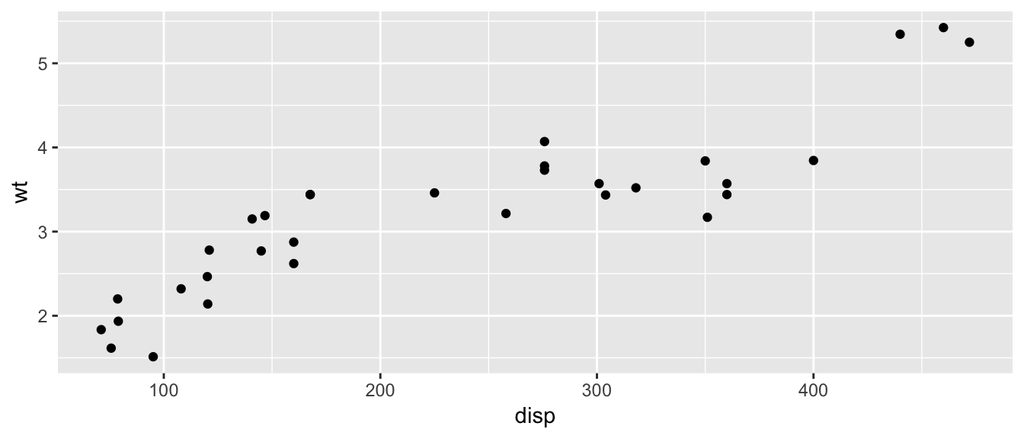

```r
ggplot(data = mtcars, aes(x=disp , y=wt)) +
       geom_point()
```

Şimdi de bu grafiğe renk ekleyelim. Renk eklemek için `color` parametresini kullanıyoruz. Bu parametreyi, hangi katmanı renklendirmek istiyorsak o katmana (bu örnekte geom_point katmanı) içine ekliyoruz.

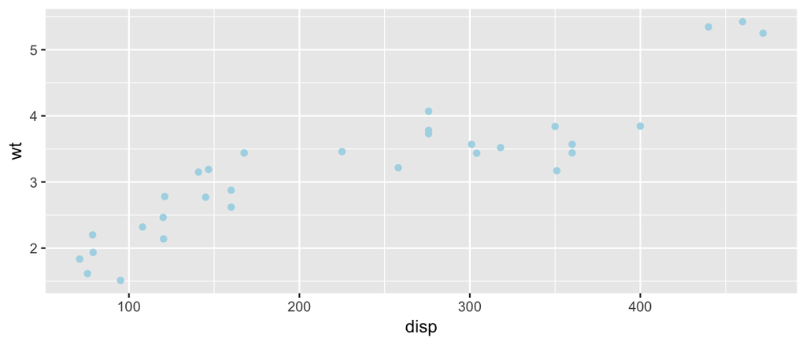

```r
ggplot(data = mtcars, aes(x=disp , y=wt)) +
       geom_point(color= "lightblue")
```

Şimdi de yeni bir katman eklemeyi deneyelim. Yeni katmanı daha önceki gibi `+` karakteri ile ekliyoruz. Bu katmanda, eldeki verilere göre lineer regresyon çizgisi ekleyeceğiz. Bu amaçla geom_smooth katmanını kullanacağız. Burada method parametresi olarak `lm` (linear smoothing), `glm` (generalised linear smooths) veya `loess` (local smooths) kullanabiliriz. Bu katmanın rengi da “koyu mavi” olsun.

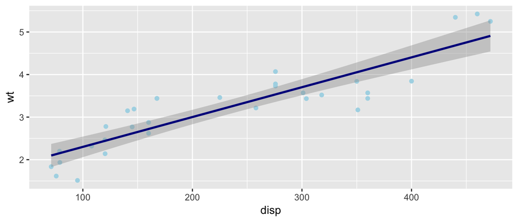

```r
ggplot(data = mtcars, aes(x=disp , y=wt)) +
       geom_point(color= "lightblue") +
       geom_smooth(method='lm', color = "darkblue")
```

Eksen adlarını değiştirmek, başlık, altbaşlık veya altyazı eklemek için de yeni bir katman ekleyebiliriz. Bu amaçla `labs` katmanını kullanıyoruz. Bu katman içinde `title` ile başlığı; `subtitle` ile altbaşlığı, `x` ile yatay ekseni, `y` ile dikey ekseni, `caption` ile de altyazıyı ekleyebiliriz.

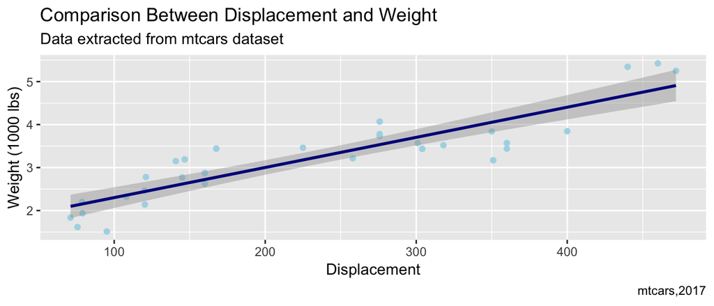

```r
ggplot(data = mtcars, aes(x=disp , y=wt)) +
       geom_point(color= "lightblue") +
       geom_smooth(method='lm', color = "darkblue") +
       labs(title = "Comparison Between Displacement and Weight",
            subtitle = "Data extracted from mtcars dataset",
            x = "Displacement",
            y= "Weight (1000 lbs)",
            caption = "mtcars,2017")
```

Bu yazıda sadece ggplot paketinin prensibinden ve örnek uygulamalarından bahsettik. Konu ile ilgili daha fazla görsellere ileride yer vereceğiz. Dağılım grafiği gibi başka onlarca tipte grafiği bu pakette hazırlamak mümkün.

Örneğin,

- Dikey veya yatay referan çizgileri eklemek için **geom_abline**,
- Çubuk tipi grafikler çizmek için **geom_bar**,
- Hekzagonal sıcaklık haritası (heatmap) için **geom_bin2d**,
- Kutu tipi grafik (boxplot) oluşturmak için **geom_boxplot**,
- 3 boyutlu dağılımların 2 boyuttaki izdüşümlerini oluşturmak için **geom_contour**,
- Histogram veya yoğunluk grafiği oluşturmak için **geom_density** veya **geom_density_2d**,
- Nokta tipi histogram için **geom_dotplot**,
- Çizgi tipi grafik oluşturmak için **geom_line** ve benzeri onlarca katmanı kullanabilirsiniz.

Daha fazlası için [Winston Chang](http://www.oreillynet.com/pub/au/5118) tarafından hazırlanmış olan **R Graphics Cookbook: Practical Recipes for Visualizing Data** kitabını edinebilirsiniz. Kitabın ücretsiz çevrim içi versiyonuna [bu adresten](http://www.cookbook-r.com/Graphs/) erişebilirsiniz. Veya Pandora Kitabevi’nden özel sipariş ile temin edebilirsiniz. Genellikle yurt dışı satış fiyatı üzerinden çok az bir oran komisyon ile getirebiliyorlar.

**Can Holyavkin**

E-posta | [Linkedin](https://www.linkedin.com/in/can-holyavkin/) | [Twitter](https://twitter.com/CanHolyavkin)